# MScA, Bayesian Methods (32014) Week 7 Workshop, Part 1

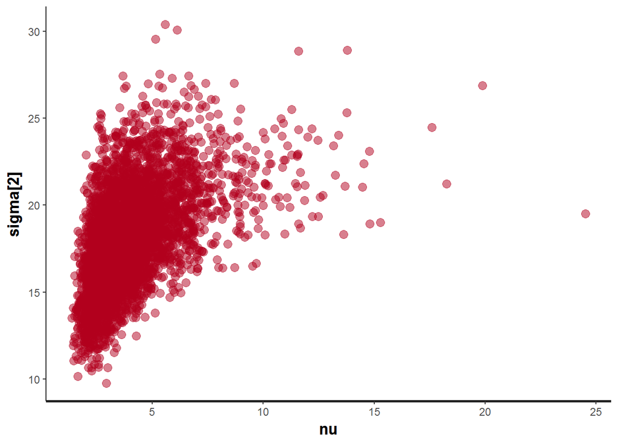

```r
stan_scat(stanFitRobust, c('nu','sigma[2]'))
```

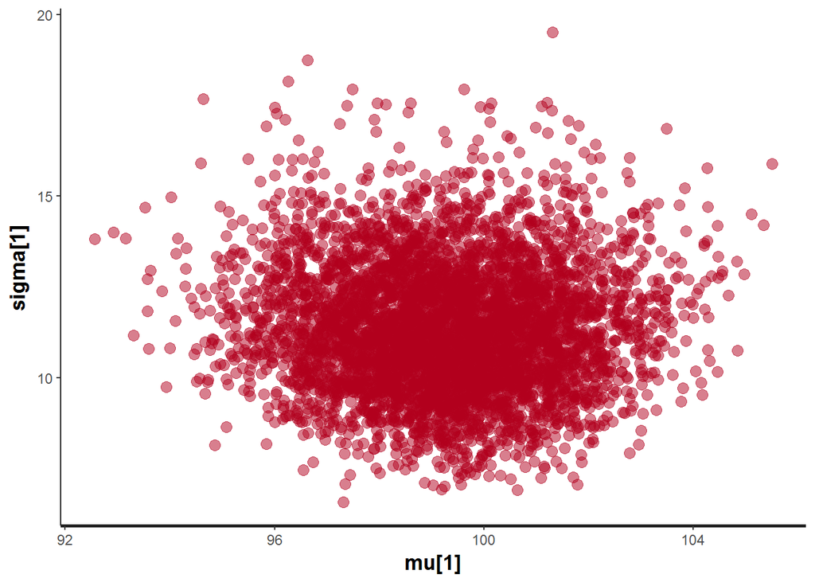

```r
stan_scat(stanFitRobust, c('mu[1]','sigma[1]'))
```

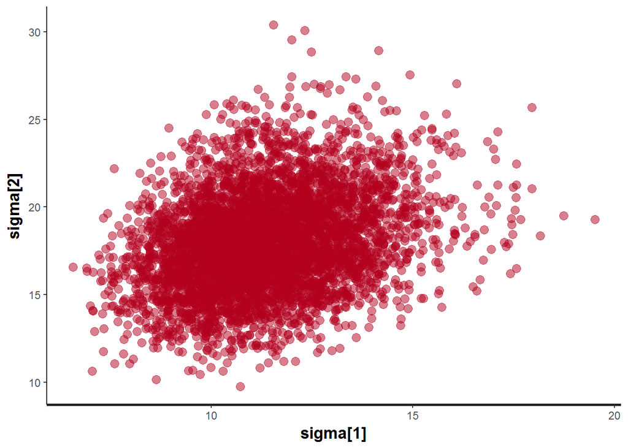

```r
stan_scat(stanFitRobust, c('sigma[1]','sigma[2]'))
```

Note correlation between the sigma parameters.  
**Is there a sign of correlation in non-robust approach?**  
**How can you explain positive correlation?**

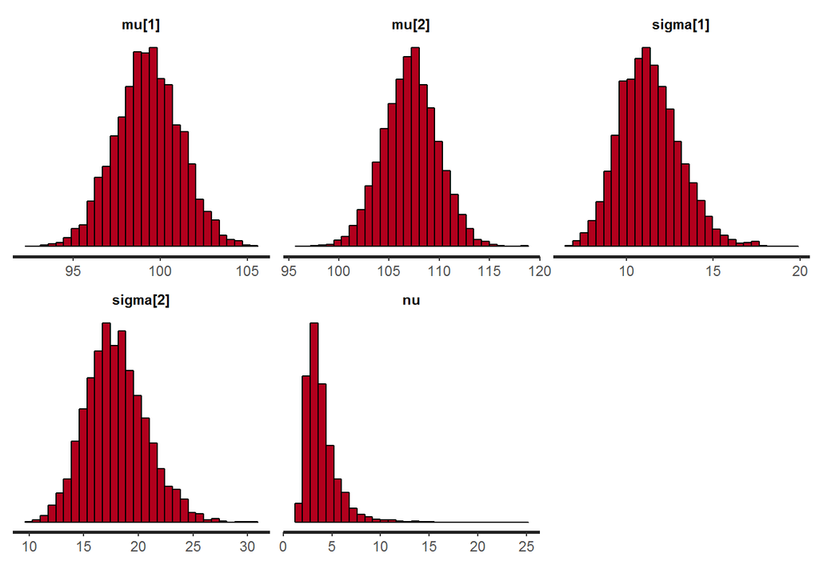

```r
stan_hist(stanFitRobust)
```

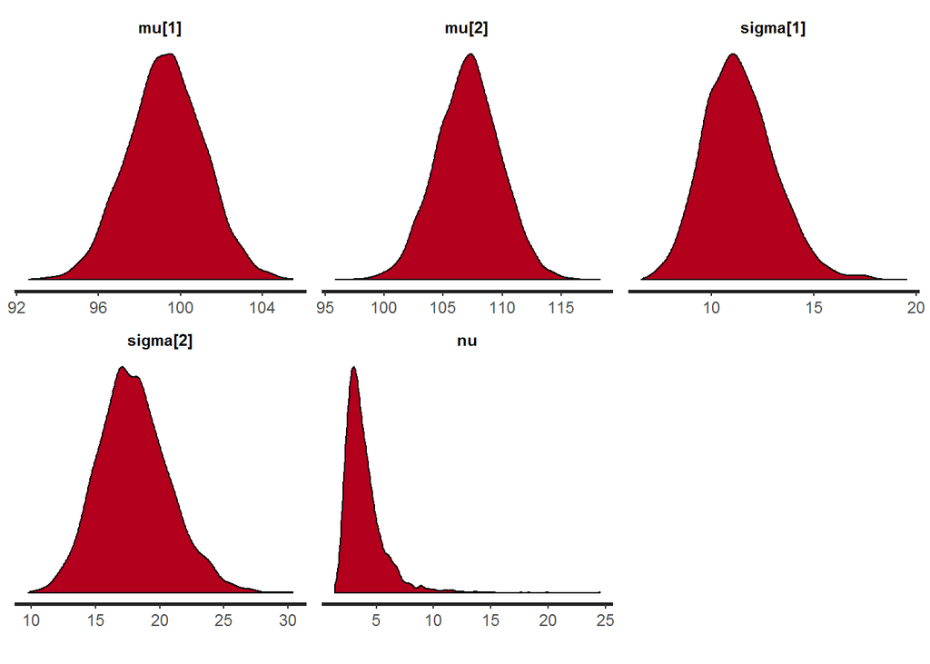

```r
stan_dens(stanFitRobust)
```

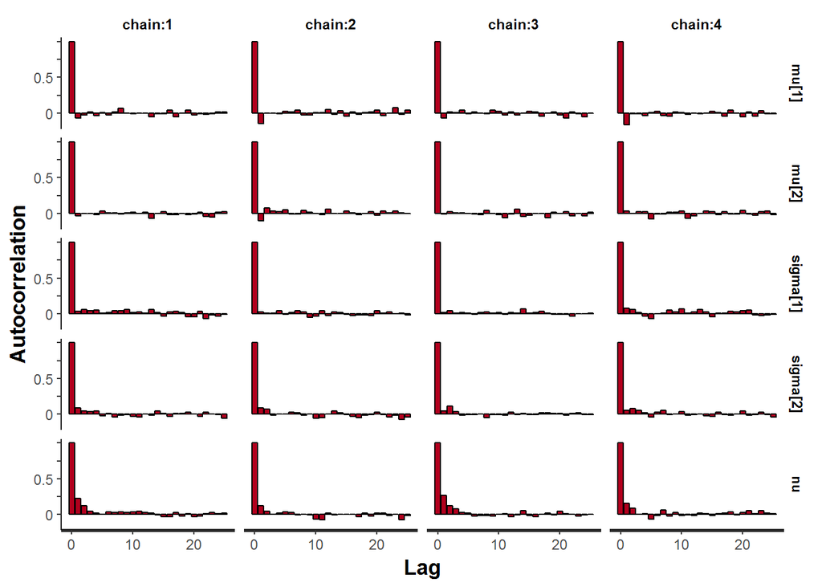

```r
stan_ac(stanFitRobust, separate_chains = T)
```

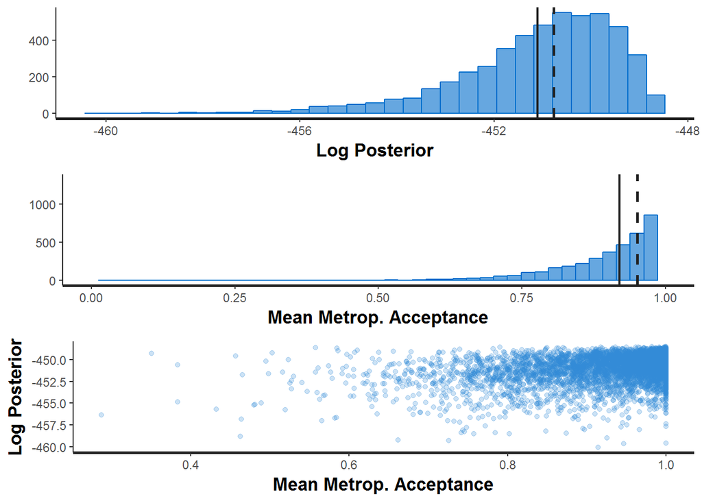

```r
stan_diag(stanFitRobust,information = "sample",chain=0)
```

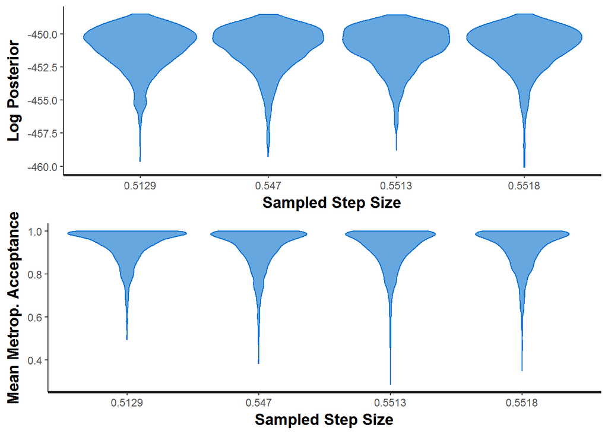

```r
stan_diag(stanFitRobust,information = "stepsize",chain = 0)
```

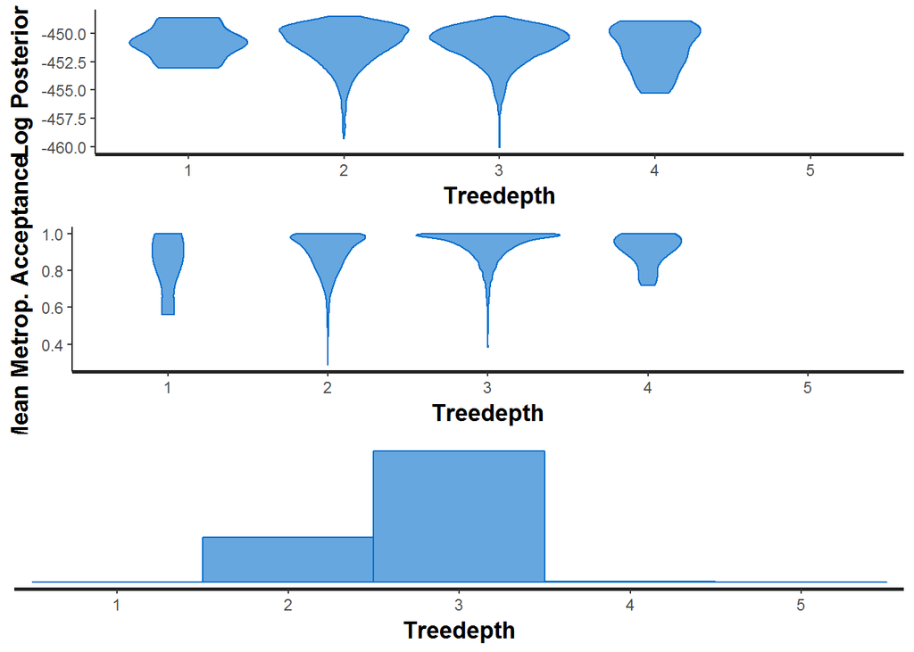

```r
stan_diag(stanFitRobust,information = "treedepth",chain = 0)
```

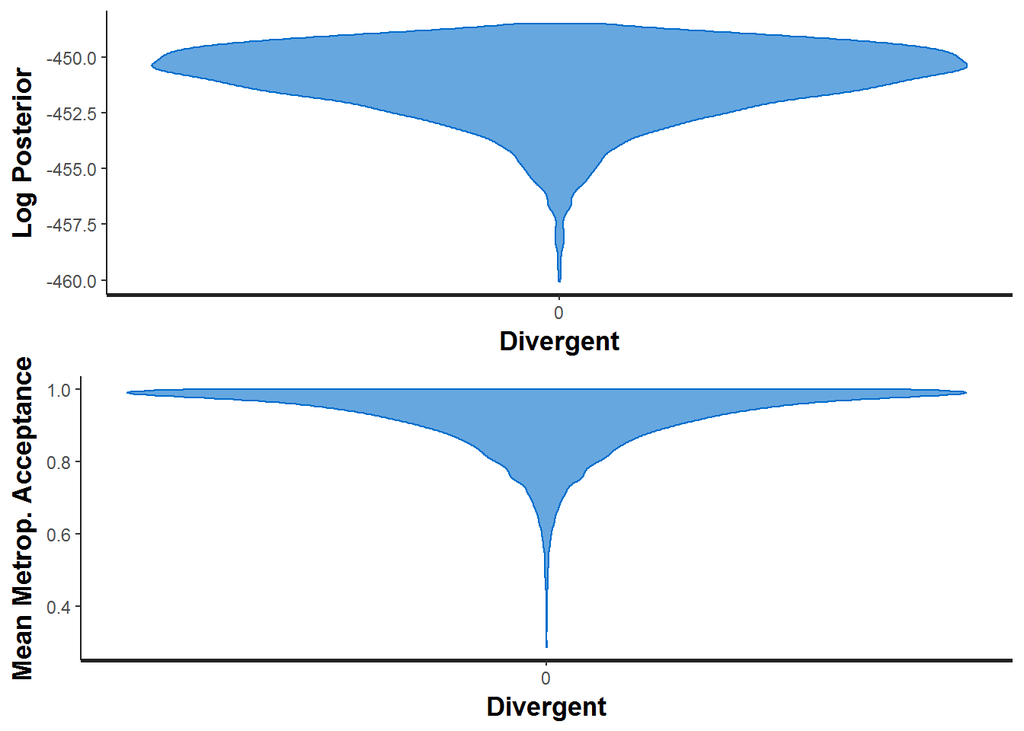

```r
stan_diag(stanFitRobust,information = "divergence",chain = 0)
```

```r
launch_shinystan(stanFitRobust)
```

# 3 Comparison of the groups

## 3.1 FNP approach

For comparison decide whether the two groups are different or not using the FNP approach.

Use t-test with unequal variances:

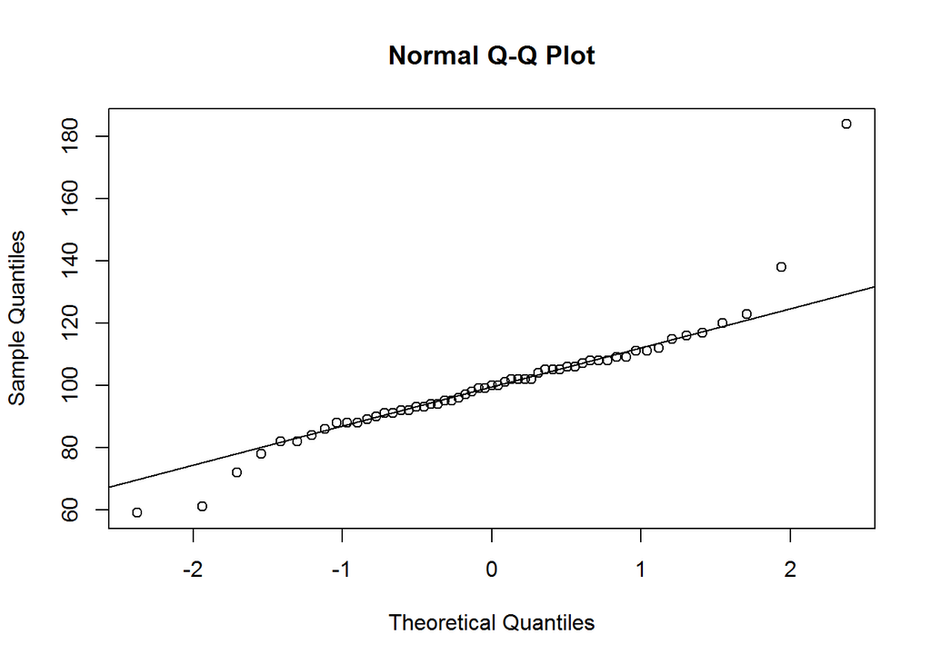

```r
qqnorm(y[x==1])
qqline(y[x==1])
```

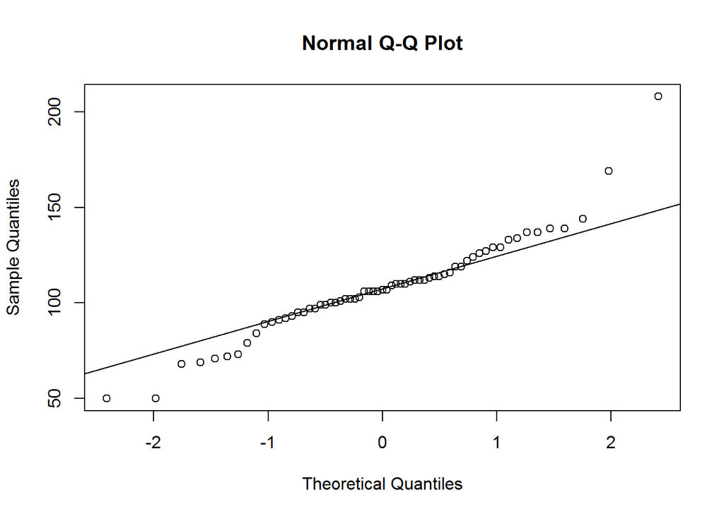

```r
qqnorm(y[x==2])
qqline(y[x==2])
```

```r
t.test(y[x==1],y[x==2], var.equal=F, paired=FALSE)
```

```
##
##  Welch Two Sample t-test
##
## data:  y[x == 1] and y[x == 2]
## t = -1.958, df = 111.44, p-value = 0.05273
## alternative hypothesis: true difference in means is not equal to 0
## 95 percent confidence interval:
##  -15.70602585   0.09366161
## sample estimates:
## mean of x mean of y
##  100.0351  107.8413
```

Result: with 5% level the hypothesis about equality of the 2 samples cannot be rejected.  
However, the case is not so clear: the p-value of the test is very close to 5%.  
The result is not very conclusive because the sample is not very long: 120 observations in both groups together.  
The test relies on the assumption that distributions of both samples are Gaussian.  
As we can see in qq-plots this assumption does not hold.

## 3.2 Bayesian approach

Now use Bayesian approach based on robust estimation.

Create matrices of combined chains for the two means and two standard deviations of the robust fit.

```r
summary(stanFitRobust)
```

```
## $summary
##                 mean    se_mean       sd        2.5%         25%
## mu[1]      99.286131 0.02624222 1.855605   95.661985   98.054235
## mu[2]     107.117606 0.03859213 2.728876  101.805886  105.265002
## sigma[1]   11.354894 0.02727855 1.742358    8.278892   10.112948
## sigma[2]   17.989399 0.04589227 2.774482   12.933870   16.082803
## nu          3.917693 0.03150614 1.712640    1.980140    2.822549
## lp__     -451.097009 0.03788227 1.658812 -455.319518 -451.903027
##                  50%         75%       97.5%    n_eff      Rhat
## mu[1]      99.281490  100.546751  102.947444 5000.000 0.9994715
## mu[2]     107.143583  108.927063  112.482378 5000.000 0.9999035
## sigma[1]   11.220322   12.437806   15.045547 4079.739 0.9998530
## sigma[2]   17.839727   19.714121   23.945840 3654.979 0.9998903
## nu          3.498721    4.515904    8.322736 2954.894 0.9998165
## lp__     -450.769616 -449.891528 -448.898303 1917.441 1.0018556
##
## $c_summary
## , , chains = chain:1
##
##           stats
## parameter         mean       sd        2.5%         25%         50%
##   mu[1]      99.271484 1.825092   95.887712   98.040322   99.255560
##   mu[2]     107.033093 2.707063  101.854008  105.160834  106.991067
##   sigma[1]   11.364583 1.785346    8.165283   10.088493   11.213672
##   sigma[2]   18.004626 2.827515   12.971167   16.046388   17.905797
##   nu          3.942579 1.867453    1.940347    2.773286    3.486479
##   lp__     -451.123773 1.728894 -455.687308 -451.931539 -450.760078
##           stats
## parameter         75%       97.5%
##   mu[1]     100.51029  102.702395
##   mu[2]     108.89076  112.447746
##   sigma[1]   12.52017   15.029758
##   sigma[2]   19.77882   24.021524
##   nu          4.49971    9.008494
##   lp__     -449.85574 -448.909278
##
## , , chains = chain:2
##
##           stats
## parameter         mean       sd        2.5%         25%         50%
```

[output cut: 37 more lines]

```
## parameter        mean       sd        2.5%         25%        50%
##   mu[1]      99.32888 1.892300   95.436596   98.023339   99.37482
##   mu[2]     107.08501 2.729746  101.624390  105.306243  107.17014
##   sigma[1]   11.30595 1.703186    8.396176   10.070371   11.19915
##   sigma[2]   17.88969 2.813001   12.629255   15.950286   17.68515
##   nu          3.88456 1.596962    1.975928    2.815901    3.50223
##   lp__     -451.12336 1.632743 -455.299426 -451.984644 -450.79512
##           stats
## parameter          75%       97.5%
##   mu[1]     100.664833  102.998859
##   mu[2]     108.841026  112.604375
##   sigma[1]   12.343605   14.901380
##   sigma[2]   19.738580   23.913028
##   nu          4.554557    7.848539
##   lp__     -449.920617 -448.894656
```

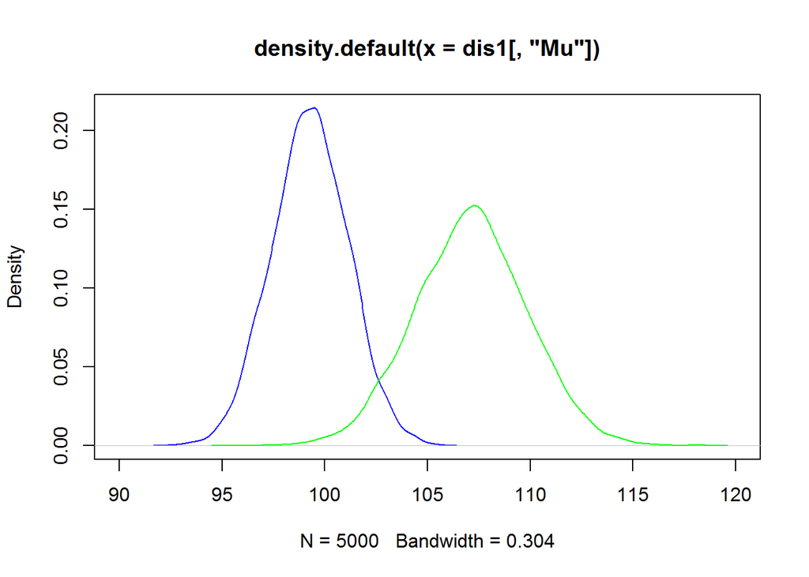

```r
dis1<-cbind(Mu=rstan::extract(stanFitRobust,pars="mu[1]")$'mu[1]',
            Sigma=rstan::extract(stanFitRobust,pars="sigma[1]")$'sigma[1]')
dis2<-cbind(Mu=rstan::extract(stanFitRobust,pars="mu[2]")$'mu[2]',
            Sigma=rstan::extract(stanFitRobust,pars="sigma[2]")$'sigma[2]')
denDis1<-density(dis1[,"Mu"])
denDis2<-density(dis2[,"Mu"])
plot(denDis1,col="blue",xlim=c(90,120))
lines(denDis2,col="green")
```

Traditional Bayesian approach: look at HDIs.

```r
library(HDInterval)
hdi(cbind(dis1[,1],dis2[,1]),credMass=.9)
```

```
##            [,1]     [,2]
## lower  96.21772 102.6369
## upper 102.26362 111.5602
## attr(,"credMass")
## [1] 0.9
```

```r
hdi(cbind(dis1[,2],dis2[,2]),credMass=.85)
```

```
##            [,1]     [,2]
## lower  8.779203 13.92627
## upper 13.691654 21.71945
## attr(,"credMass")
## [1] 0.85
```

The 95% HDI intervals overlap for both parameters, but with reduced credible mass level they can be distinguished.

## 3.3 FNP approach to Markov chains

Apply FNP approach to the chain samples.

First, check if the samples for two standard deviations are significantly different or not:

```r
c(mean(dis1[,2]),mean(dis2[,2])) # mean values
```

```
## [1] 11.35489 17.98940
```

```r
c(sd(dis1[,2]),sd(dis2[,2]))     # standard deviations of samples of MCMC standard deviations
```

```
## [1] 1.742358 2.774482
```

```r
ks.test(dis1[,2],dis2[,2])       #Kolmogorov-Smirnov test for posterior distributions of standard deviations
```

```
##
##  Two-sample Kolmogorov-Smirnov test
##
## data:  dis1[, 2] and dis2[, 2]
## D = 0.8684, p-value < 2.2e-16
## alternative hypothesis: two-sided
```

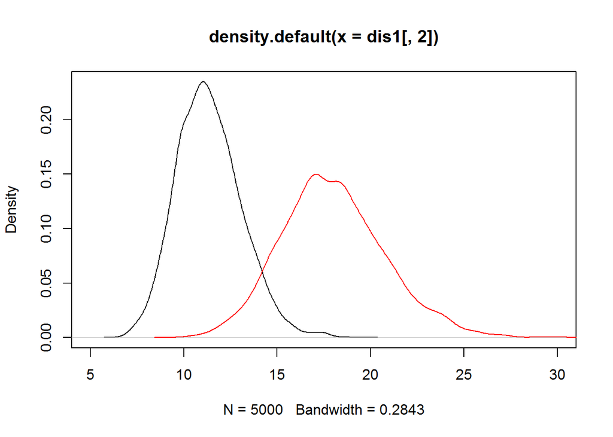

```r
den<-density(dis2[,2])
plot(density(dis1[,2]),xlim=c(5,30))
lines(den$x,den$y,col="red")
```

```r
t.test(dis1[,2],dis2[,2], var.equal=F, paired=FALSE) #t-test for means of posterior distributions for standard deviations
```

```
##
##  Welch Two Sample t-test
##
## data:  dis1[, 2] and dis2[, 2]
## t = -143.19, df = 8411.3, p-value < 2.2e-16
## alternative hypothesis: true difference in means is not equal to 0
## 95 percent confidence interval:
##  -6.725329 -6.543682
## sample estimates:
## mean of x mean of y
##  11.35489  17.98940
```

Comparison of mean and standard deviations of the posterior sample for standard deviations, Kolmogorov-Smirnov test, density plots and t-test for the two samples all indicate that the variances of the two groups are different.

This means that we cannot apply ANOVA to compare the two group mean values directly.

Try t-test for the two means of the posterior distributions with different variances:

```r
t.test(dis1[,1],dis2[,1], var.equal=F, paired=FALSE)
```

```
##
##  Welch Two Sample t-test
##
## data:  dis1[, 1] and dis2[, 1]
## t = -167.81, df = 8807.6, p-value < 2.2e-16
## alternative hypothesis: true difference in means is not equal to 0
## 95 percent confidence interval:
##  -7.922957 -7.739993
## sample estimates:
## mean of x mean of y
##  99.28613 107.11761
```

The null hypothesis of equality of the means of the posterior distributions for the mean values of the two groups decisively rejected: we are testing with a lot longer samples.

Plot the images of the two groups in the mean-standard deviation parameter space:

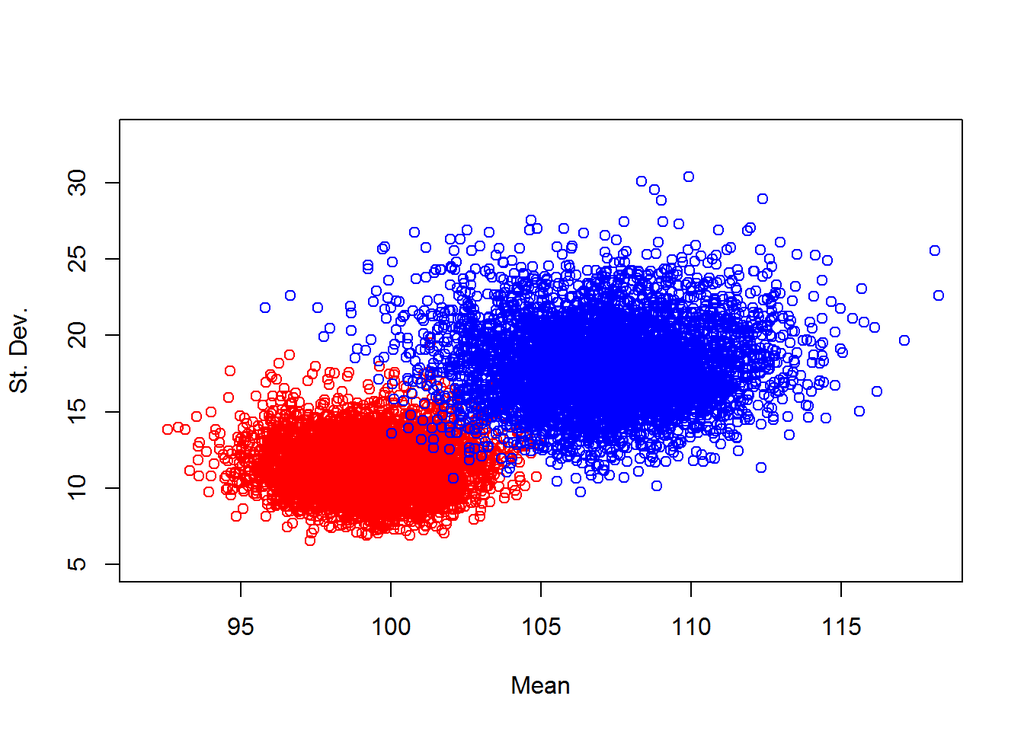

```r
plot(dis1,xlim=c(92,118),ylim=c(5,33),col="red",xlab="Mean",ylab="St. Dev.")
points(dis2,col="blue")
```

Use at least 2 different methods proving that there is a significant difference between the 2 groups shown on the plot.